# Eco2Urb data

```r
setwd("/Users/Ty/Dropbox/Dendritic connectivity/SUS2020/data/Eco2Urb")
library(sf)
```

```r
library(ggplot2)
library(raster)
library(tiff)
```

```r
list.files()
```

```
##  [1] "Biodiversity_module.R"           "CanALE_module.R"
##  [3] "dropoutPanelSus.R"               "Eco2Urb_Data_processing.nb.html"
##  [5] "Eco2Urb_Data_processing.Rmd"     "languageSwitchSus.R"
##  [7] "Mode_shift_module.R"             "Pedestrian_realm.R"
##  [9] "rightPanelSus.R"                 "scrollingTimelingSus.R"
## [11] "speciesOccDataSus.R"             "titletextSus.R"
## [13] "translation_functions.R"         "zoomMenuItemSus.R"
## [15] "zoomMenuSus.R"
```

```r
setwd("/Users/Ty/Dropbox/Dendritic connectivity/SUS2020/data/Eco2Urb/DSF2FinalRasters")
list.files()
```

```
##  [1] "Fig11a.asc"          "Fig11a.asc.aux.xml"  "Fig11a.asc.ovr"
##  [4] "Fig11b.asc"          "Fig11b.asc.aux.xml"  "Fig11b.asc.ovr"
##  [7] "Fig11c.asc"          "Fig11c.asc.aux.xml"  "Fig11c.asc.ovr"
## [10] "Fig13.tif"           "Fig13.tif.aux.xml"   "Fig13.tif.ovr"
## [13] "Fig14.asc"           "Fig14.asc.aux.xml"   "Fig14.asc.ovr"
## [16] "Fig14.tif"           "Fig15.tif"           "Fig15.tif.aux.xml"
## [19] "Fig15.tif.ovr"       "Fig16.tif"           "Flood_CMM.tif"
## [22] "Flood_CMM.tif.zip"   "heatcoolislands"     "heatcoolislands.zip"
```

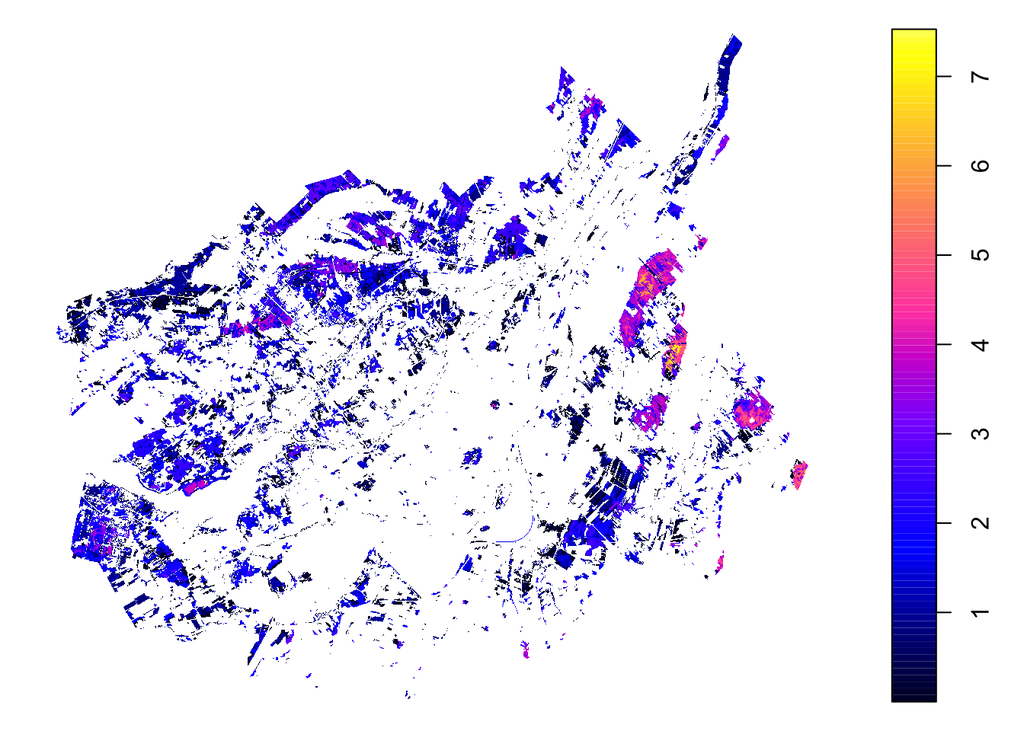

```r
tiff_11A <- read.asciigrid("/Users/Ty/Dropbox/Dendritic connectivity/SUS2020/data/Eco2Urb/DSF2FinalRasters/Fig11a.asc")

plot(tiff_11A)
```

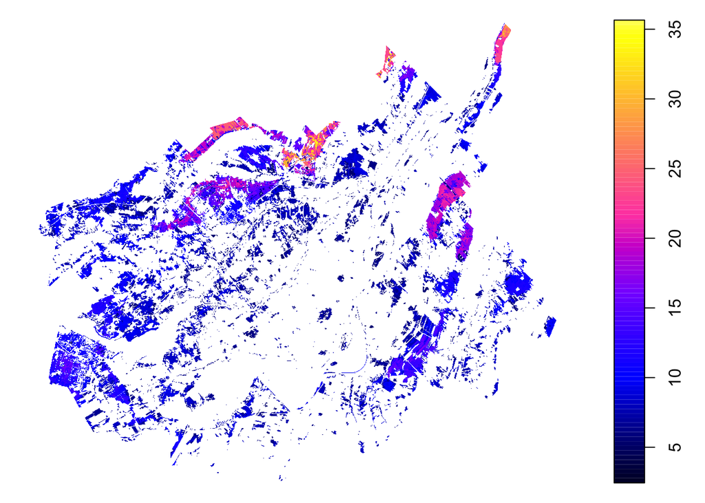

```r
tiff_11B <- read.asciigrid("/Users/Ty/Dropbox/Dendritic connectivity/SUS2020/data/Eco2Urb/DSF2FinalRasters/Fig11b.asc")

plot(tiff_11B)
```

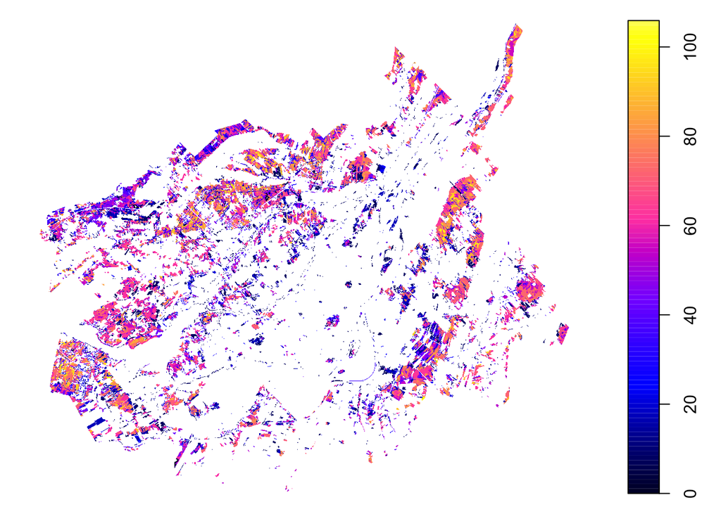

```r
tiff_11C <- read.asciigrid("/Users/Ty/Dropbox/Dendritic connectivity/SUS2020/data/Eco2Urb/DSF2FinalRasters/Fig11c.asc")

plot(tiff_11C)
```

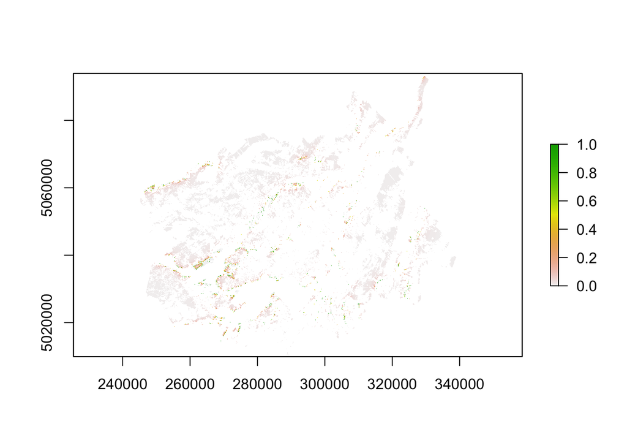

```r
tiff_13 <- raster("/Users/Ty/Dropbox/Dendritic connectivity/SUS2020/data/Eco2Urb/DSF2FinalRasters/Fig13.tif")

plot(tiff_13)
```

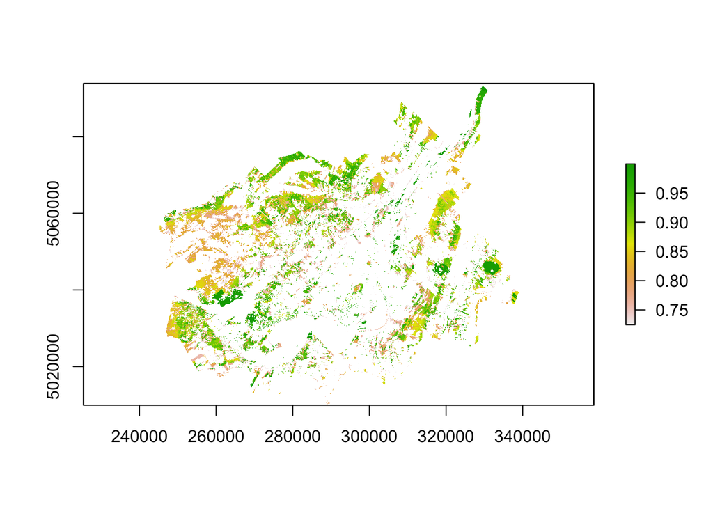

```r
tiff_14 <- raster("/Users/Ty/Dropbox/Dendritic connectivity/SUS2020/data/Eco2Urb/DSF2FinalRasters/Fig14.tif")
plot(tiff_14)
```

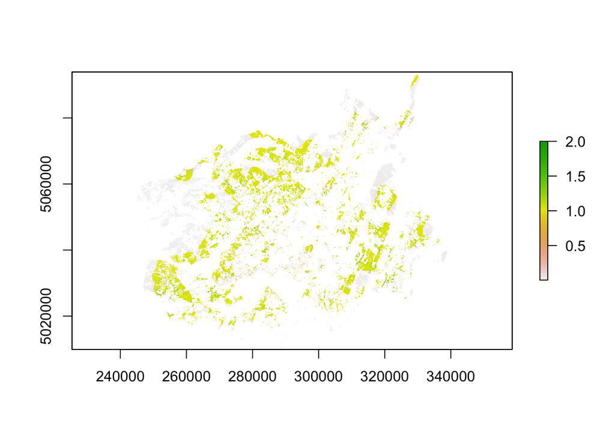

```r
tiff_15 <- raster("/Users/Ty/Dropbox/Dendritic connectivity/SUS2020/data/Eco2Urb/DSF2FinalRasters/Fig15.tif")
plot(tiff_15)
```

[figure not shown]

```r
tiff_16 <- raster("/Users/Ty/Dropbox/Dendritic connectivity/SUS2020/data/Eco2Urb/DSF2FinalRasters/Fig16.tif")

plot(tiff_16)
```

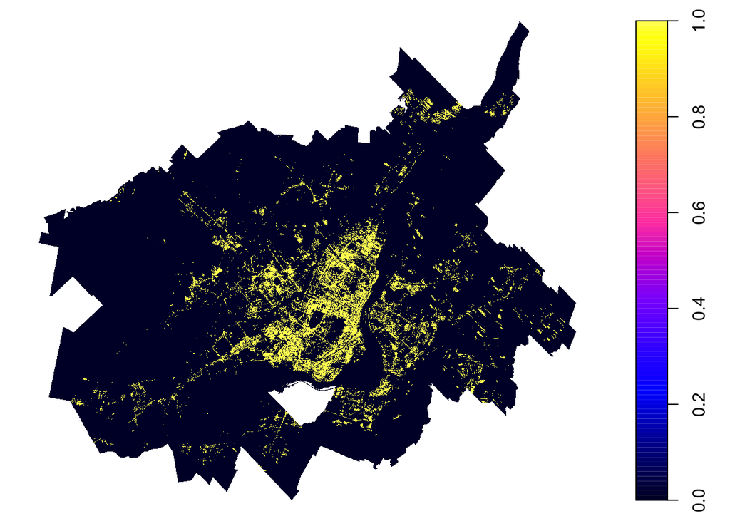

```r
heat_islands <- read.asciigrid("/Users/Ty/Dropbox/Dendritic connectivity/SUS2020/data/Eco2Urb/DSF2FinalRasters/heatcoolislands/heatislands3.asc")
cool_islands <- read.asciigrid("/Users/Ty/Dropbox/Dendritic connectivity/SUS2020/data/Eco2Urb/DSF2FinalRasters/heatcoolislands/coolislands5.asc")

plot(heat_islands)
```

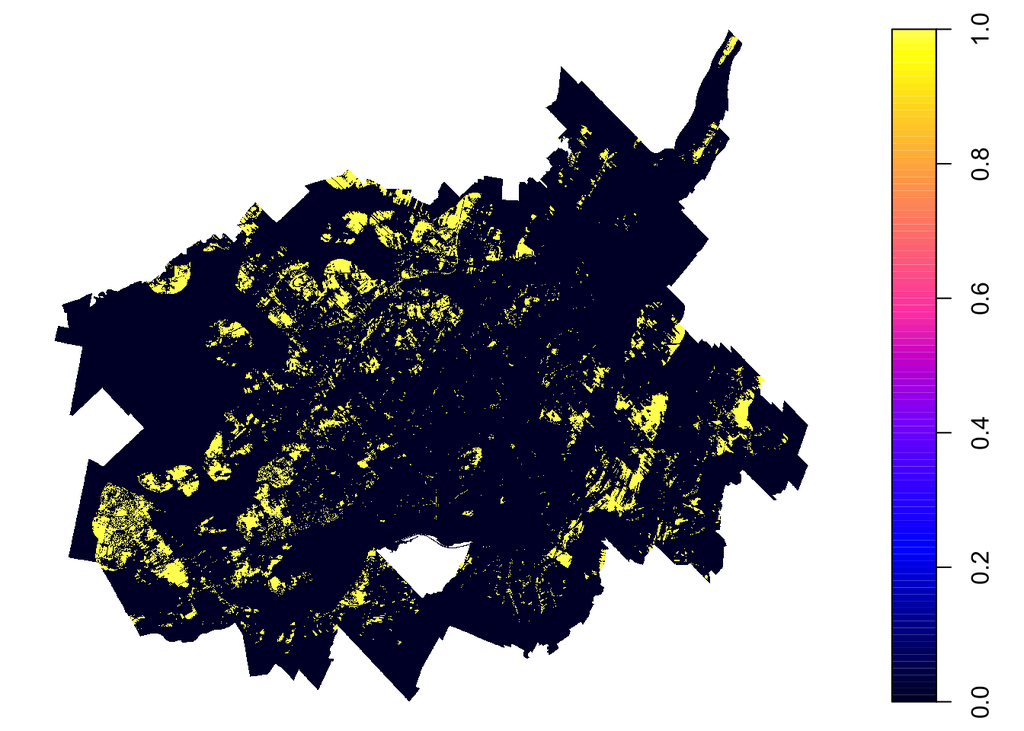

```r
plot(cool_islands)
```

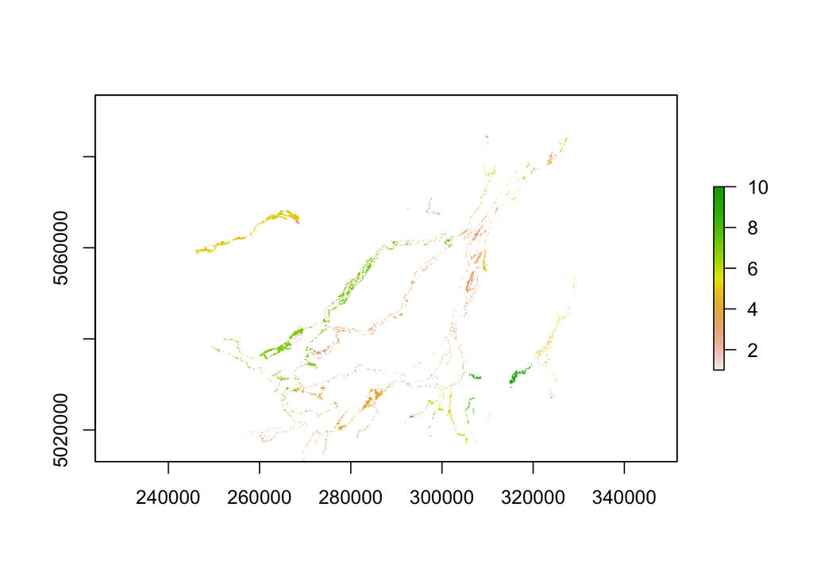

```r
flood <- raster("/Users/Ty/Dropbox/Dendritic connectivity/SUS2020/data/Eco2Urb/DSF2FinalRasters/Flood_CMM.tif/Flood_CMM.tif")
plot(flood)
```

```r
montreal_ES <- st_read("/Users/Ty/Dropbox/Dendritic connectivity/SUS2020/data/Eco2Urb/montreal-agglomeration-muni-100028-div-vf1-20201125.shp")
```

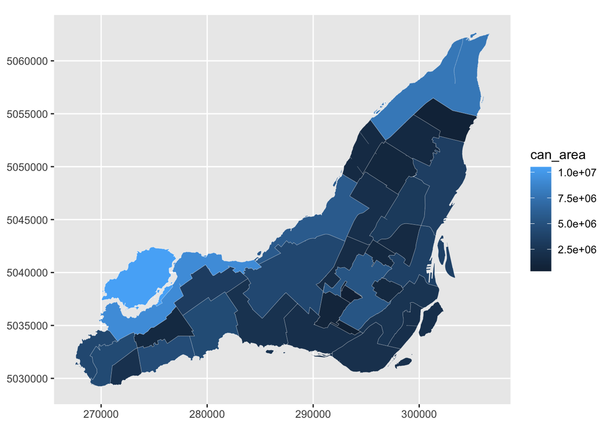

```r
ggplot(montreal_ES) +
      geom_sf(aes(fill = can_area), color = "white",
              size = 0.05)
```

```r
names(montreal_ES)
```

```
##  [1] "SP_ID"      "nom_arr"    "can_area"   "muni_area"  "perc_co"
##  [6] "sp"         "rrar"       "abun"       "trunof"     "stand_run"
## [11] "polrem"     "stand_pol"  "carbon"     "stand_car"  "Sequestrat"
## [16] "stand_seq"  "Evap"       "stand_evap" "mtl"        "order"
## [21] "cancarbon2" "canrunoffa" "canseq2"    "canpoll"    "geometry"
```

“SP_ID” [integer] = shape ID “nom_arr” [character] = name of area described by shape “can_area” [number] = ? what is can? “muni_area” [integer] = why is this an integer? “perc_co” [number] = ? “sp” [integer] = number of species observed in shape area? Is this a model or data? “rrar” [number] = ? “abun” [integer] = abundance of something? “trunof” [number] = ? “stand_run” [number]= something about water runoff? “polrem” [number]= polution remediation? “stand_pol” [number]= standing polution? “carbon” [number] = what about carbon? “stand_car” [number] = why is this a decimal if the unit is a car? is this number of cars that park in a shape? “Sequestrat”[number] = sequestering rats? “stand_seq” [number] = standing sequestration of something. “Evap” [number] = evaporation from trees? “stand_evap” [number]= standing evaporation? evaporation from standing vegetation? meaning seasonal? “mtl” [factor] = in MTL city limits or data provided by MTL? or other? “order” [factor] = ? “cancarbon2” [number]= what is special about the ‘can’ designation? Are the data from canadian federal sources? “canrunoffa”[number]= “canseq2” [number] = “canpoll” [number] = what is poll?